# Homework 4

John Doll

2/27/2020

# Problem 1

## Question 1

This is a blocked two-way anova. The block is the pain tolerance.

## Question 2

Pain tolerance should be considered because that could affect the pain relief response variable. People with a very high pain tolerance might have a lesser affect from the treatment that they are given. If we did not block for this, there would be more variability among our results due to range in pain tolerance of the subjects.

## Question 3

```r
pain <- read.csv("dentalPainData.csv")
glimpse(pain)
```

```
## Observations: 8
## Variables: 5
## $ PainTolerance <int> 1, 2, 3, 4, 5, 6, 7, 8
## $ PI            <dbl> 0.0, 0.3, 0.4, 0.4, 0.6, 0.9, 1.0, 1.2
## $ PA            <dbl> 0.6, 0.7, 0.8, 0.9, 1.5, 1.6, 1.7, 1.6
## $ CI            <dbl> 0.5, 0.6, 0.8, 0.7, 1.0, 1.4, 1.8, 1.7
## $ CA            <dbl> 1.2, 1.3, 1.6, 1.5, 1.9, 2.3, 2.1, 2.4
```

```r
pain <- pain %>%
  mutate(PainTolerance = as.factor(PainTolerance)) %>%
  pivot_longer(c(PI, PA, CI, CA), names_to = "Treatment", values_to = "PainRelief") %>%
  mutate(Codeine = as.factor(case_when(Treatment == "CI" ~ "True",
                                       Treatment == "CA" ~ "True",
                                       TRUE ~ "False")),
         Acupuncture = as.factor(case_when(Treatment == "PA" ~ "True",
                                           Treatment == "CA" ~ "True",
                                           TRUE ~ "False")))
pain
```

```
## # A tibble: 32 x 5
##    PainTolerance Treatment PainRelief Codeine Acupuncture
##    <fct>         <chr>          <dbl> <fct>   <fct>
##  1 1             PI               0   False   False
##  2 1             PA               0.6 False   True
##  3 1             CI               0.5 True    False
##  4 1             CA               1.2 True    True
##  5 2             PI               0.3 False   False
##  6 2             PA               0.7 False   True
##  7 2             CI               0.6 True    False
##  8 2             CA               1.3 True    True
##  9 3             PI               0.4 False   False
## 10 3             PA               0.8 False   True
## # … with 22 more rows
```

Here, we mutate the variables to their proper type, switch the direction of the data from wide to long, and add two variables to better analyze the data.

## Question 4

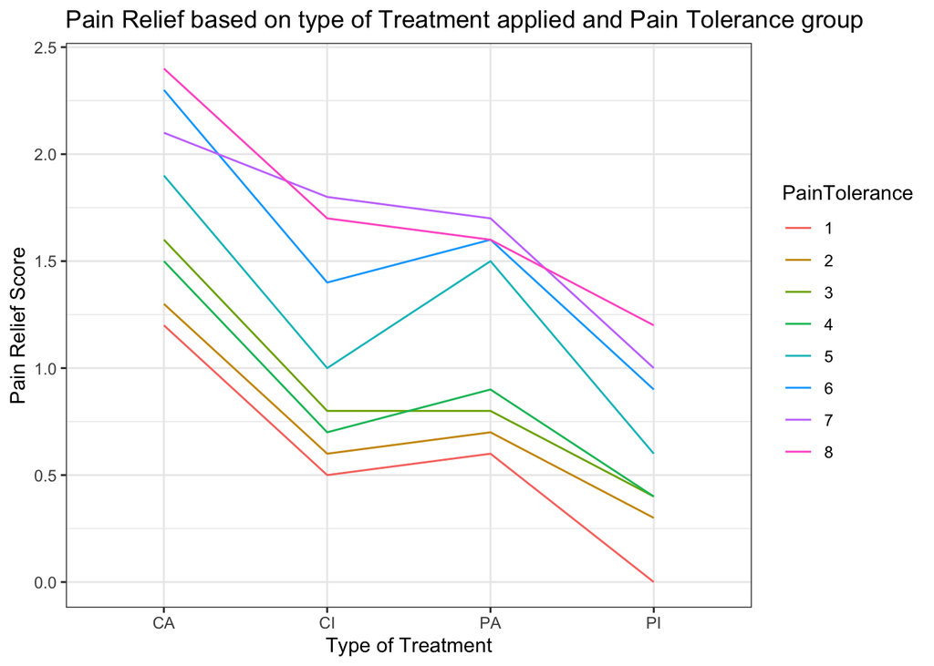

```r
ggplot(pain) +
  geom_line(aes(x = Treatment, y = PainRelief, col = PainTolerance, group = PainTolerance)) +
  labs(x = "Type of Treatment", y = "Pain Relief Score") +
  ggtitle("Pain Relief based on type of Treatment applied and Pain Tolerance group") +
  theme_bw()
```

Our data goes from left to right with codeine and acupuncture in effect, then just codeine, then just acupuncture, and finally, neither. From this graph it would appear that the codeine with the acupuncture has the greatest effect on pain relief score and that the absense of both has the least effect.